# NFL Draft Analysis: The Quarterback

Philip Ipe

5/8/2020

# Part 1: Data Collection

We will scrape historical draft data from Pro-Football Reference from years 1970 till 2016. We will filter out any selections after round 7, as since 1994, the NFL draft has only consisted of 7 rounds.

```r
master_df <- data.frame()
for (year in 1970:2016){

  draft_url <- paste("https://www.pro-football-reference.com/years/", year, "/draft.htm", sep="")
  draft_html <- read_html(draft_url)

  df <- draft_html %>%
    html_node("table") %>%
    html_table()

  names(df) <- as.character(unlist(df[1,]))
  df <- df[-1,]

  # get rid of the columns we dont care about
  df <- df[,1:13]

  df$Rnd <- as.integer(df$Rnd)
  df$Age <- as.integer(df$Age)
  df$CarAV <- as.integer(df$CarAV)
  df$DrAV <- as.integer(df$DrAV)
  df$G <- as.integer(df$G)

  # filter out certain rounds
  df <- df %>%
    filter(Rnd < 8)

  # get rid of blank rows
  df <-df[!(df$Player=="Player"),]

  # add year drafted to each observation
  df <- df %>%
    mutate(year = year)

  master_df <- rbind(master_df, df)
}
```

Next we will scrape the AP Offensive Rookie of the Year Winners from the same website.

```r
roty_url <- "https://www.pro-football-reference.com/awards/ap-offensive-rookie-of-the-year-award.htm"
draft_html <- read_html(roty_url)

roty_df <- draft_html %>%
  html_node("table") %>%
  html_table()
```

# Part 2: Data Processing and Preparation

```r
head(master_df)
```

```
##   Rnd Pick  Tm             Player Pos Age   To AP1 PB St CarAV DrAV   G year
## 1   1    1 PIT Terry Bradshaw HOF  QB  22 1983   1  3 13   106  106 168 1970
## 2   1    2 GNB         Mike McCoy  DT  22 1980   0  0  7    46   40 132 1970
## 3   1    3 CLE        Mike Phipps  QB  22 1981   0  0  5    40   32 119 1970
## 4   1    4 BOS         Phil Olsen  DT  22 1976   0  0  1    19   NA  79 1970
## 5   1    5 BUF        Al Cowlings  DE  23 1979   0  0  5    29   11 101 1970
## 6   1    6 PHI        Steve Zabel  LB  22 1979   0  0  7    38   17 124 1970
```

```r
master_df <- master_df[complete.cases(master_df[,12:13]),]
master_df$Rnd <- as.factor(master_df$Rnd)

master_df$Age <- as.integer(master_df$Age)
master_df$CarAV <- as.integer(master_df$CarAV)
master_df$DrAV <- as.integer(master_df$DrAV)
master_df$G <- as.integer(master_df$G)
master_df$Pick <- as.integer(master_df$Pick)
```

First, we want to break up our data into 4 periods. Then for each period, we will take average career value of each position grouped by each round that the player was selected. We will make a new pos_df dataframe with these groupings.

```r
pos_df <- master_df %>%
  mutate(period = cut(year, breaks=4)) %>%
  group_by(period, Pos, Rnd) %>%
  summarise(Avg_AV = mean(CarAV))

head(pos_df)
```

```
## # A tibble: 6 x 4
## # Groups:   period, Pos [1]
##   period              Pos   Rnd   Avg_AV
##   <fct>               <chr> <fct>  <dbl>
## 1 (1.97e+03,1.98e+03] C     1       32
## 2 (1.97e+03,1.98e+03] C     2       50.3
## 3 (1.97e+03,1.98e+03] C     3       12.5
## 4 (1.97e+03,1.98e+03] C     4       42
## 5 (1.97e+03,1.98e+03] C     5       26.1
## 6 (1.97e+03,1.98e+03] C     6       21.6
```

# Part 3: Exploratory Data Analysis

## Trends in Average value

Has average value for players selected in different rounds gone up over time? Have GMs gotten better at drafting in the first round, second round, etc…?

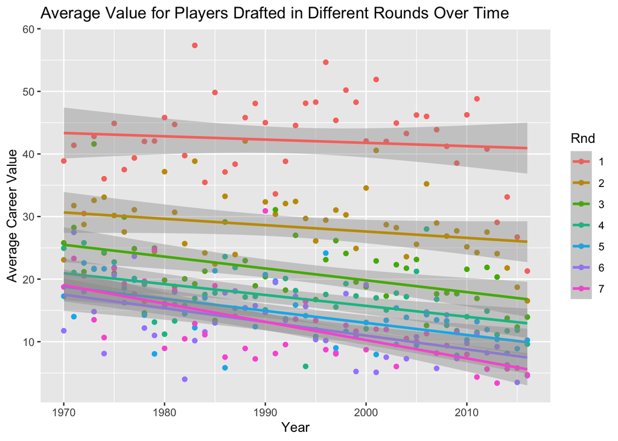

```r
avg_val_df <- master_df %>%
  group_by(year, Rnd) %>%
  summarise(Avg_AV = mean(CarAV))

avg_val_df %>%
  group_by(Rnd) %>%
  ggplot(mapping=aes(x=year, y=Avg_AV, color=Rnd)) +
    geom_point() +
    labs(x = "Year", y = "Average Career Value", title = "Average Value for Players Drafted in Different Rounds Over Time") +
    geom_smooth(method=lm)
```

## Analyzing the Quarterback position

Lets analyze the average values of different positions grouped by round and time period in which they were drafted. Let’s start with the most important position in football.

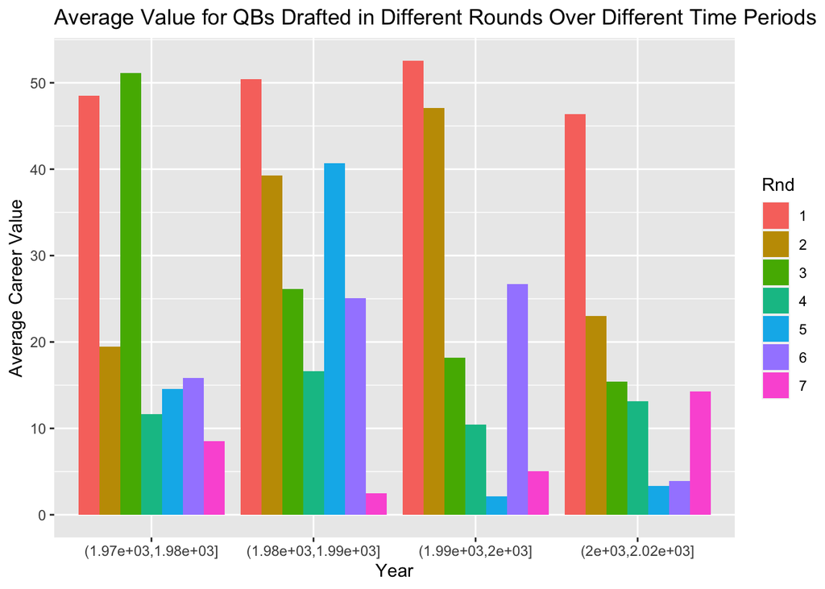

```r
qb_bar <- pos_df %>%
  filter(Pos == "QB") %>%
  group_by(Rnd) %>%
  ggplot(mapping=aes(x=period, y=Avg_AV, fill=Rnd)) +
    geom_bar(stat="identity", position = "dodge") +
    labs(x = "Year", y = "Average Career Value", title = "Average Value for QBs Drafted in Different Rounds Over Different Time Periods")

qb_bar
```

In the past 20 years (2000-2020), it is much more likely to hit on a QB in the first round than in any of the other rounds. We see a huge drop in average value after the first round in the past 20 years. Average value dips in half after that, and continues to decrease until the 7th round. It is interesting to note that the 7th round averge value shoots up again to about the same average values of the 3rd and 4th round in the 2000s.

Before then, from 1990-2000, we see that the 6th round was a value pick for QB, although Tom Brady might be the outlier that is skewing those numbers. But we also see that there was far more value in the second round QB selection from 1980-2000 than in the past 20 years.

Now let’s focus our attention on the past 20 years and graph some visualizations of that data.

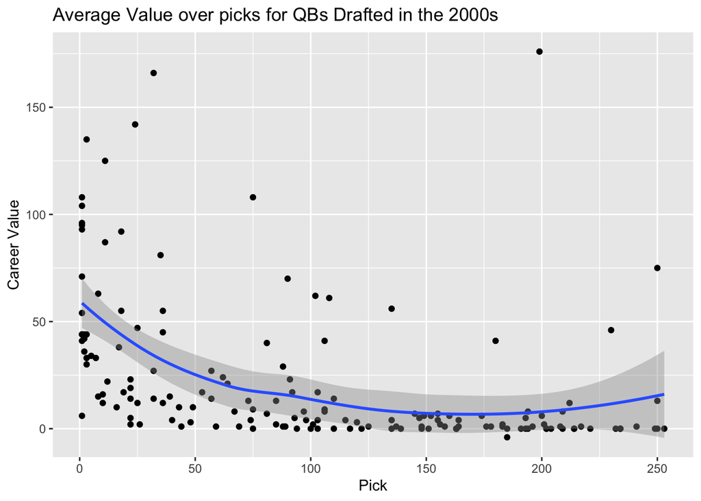

```r
qb_av_pick <- master_df %>%
  filter(year >= 2000) %>%
  filter(Pos == "QB") %>%
  ggplot(mapping=aes(x=Pick, y=CarAV)) +
    geom_point()  +
    labs(x = "Pick", y = "Career Value", title = "Average Value over picks for QBs Drafted in the 2000s") +
    geom_smooth(method='loess')

qb_av_pick
```

As we would expect the trend is that there is a decline in value until about pick 100, where the career value seems to be about the same from about pick 100-250. This would suggest that seelcting a QB at picks 100-150 would, statistically speaking, provide less bang for your buck, as you could likely get a player of the same quality with some of your later draft capital.

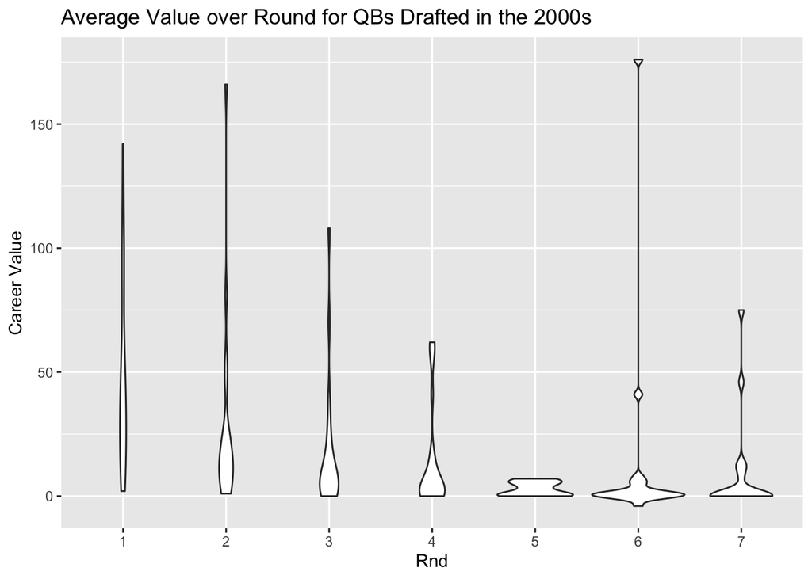

```r
qb_violin <- master_df %>%
  filter(year >= 2000) %>%
  filter(Pos == "QB") %>%
  ggplot(mapping=aes(x=factor(Rnd), y=CarAV)) +
    geom_violin()  +
    labs(x = "Rnd", y = "Career Value", title = "Average Value over Round for QBs Drafted in the 2000s") +
    geom_smooth(method=lm)

qb_violin
```

As we would expect, the violin plots show us that most of the QBs selected in rounds 5-7 turn out to be busts, as most of the career values end up towards the bottom of the violin.

## Analyzing the WR and RB positions

Next we will provide the same graphs to provide similar insight into the RB and WR selections of the draft.

It is interesting to note that the general trend has been to select RBs later in the draft, as RBs have always been considered as more expendable than a QB, and there seems to be a notion that you can always get a quality back in the later rounds, and that using first round capital on a RB is a poor management decision.

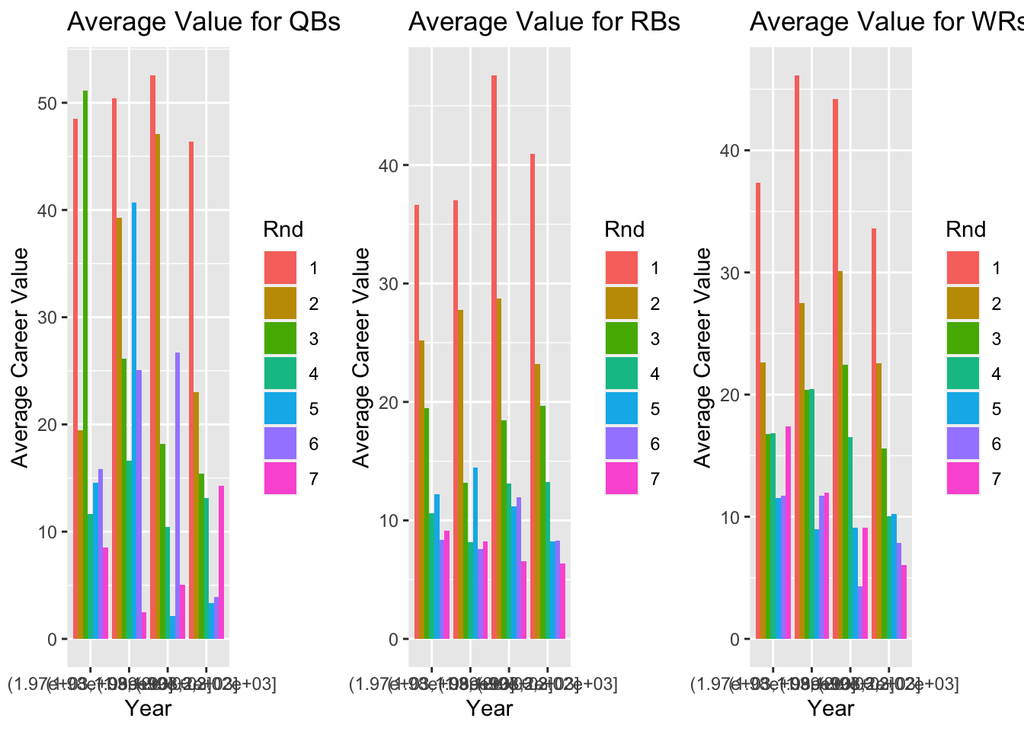

```r
rb_bar <- pos_df %>%
  filter(Pos == "RB") %>%
  group_by(Rnd) %>%
  ggplot(mapping=aes(x=period, y=Avg_AV, fill=Rnd)) +
    geom_bar(stat="identity", position = "dodge") +
    labs(x = "Year", y = "Average Career Value", title = "Average Value for RBs Drafted in Different Rounds Over Different Time Periods")

wr_bar <- pos_df %>%
  filter(Pos == "WR") %>%
  group_by(Rnd) %>%
  ggplot(mapping=aes(x=period, y=Avg_AV, fill=Rnd)) +
    geom_bar(stat="identity", position = "dodge") +
    labs(x = "Year", y = "Average Career Value", title = "Average Value for WRs Drafted in Different Rounds Over Different Time Periods")

grid.arrange(qb_bar, rb_bar, wr_bar, ncol=3)
```

Not as drastic of a difference in rounds 1 and 2 in the WR group. The RB average value in the 2000s seems to resemble the QB position.

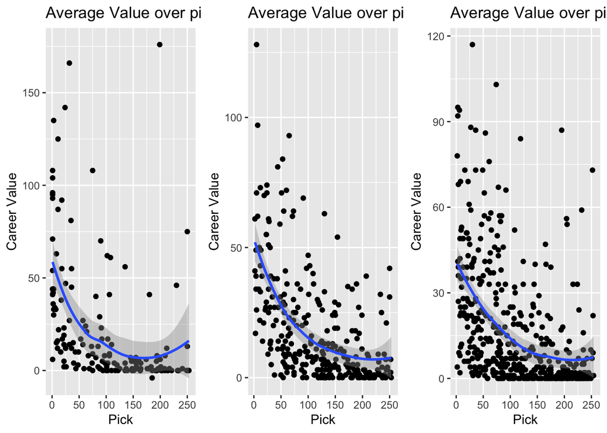

```r
rb_av_pick <- master_df %>%
  filter(year >= 2000) %>%
  filter(Pos == "RB") %>%
  ggplot(mapping=aes(x=Pick, y=CarAV)) +
    geom_point()  +
    labs(x = "Pick", y = "Career Value", title = "Average Value over picks for RBs") +
    geom_smooth(method='loess')

wr_av_pick <- master_df %>%
  filter(year >= 2000) %>%
  filter(Pos == "WR") %>%
  ggplot(mapping=aes(x=Pick, y=CarAV)) +
    geom_point()  +
    labs(x = "Pick", y = "Career Value", title = "Average Value over picks for WRs") +
    geom_smooth(method='loess')

grid.arrange(qb_av_pick, rb_av_pick, wr_av_pick, ncol=3)
```

Much less steep of a drop off between round 1 to 2 in the WR group.

Again we see a trend that by pick 100 the value seems to hit a plateue.

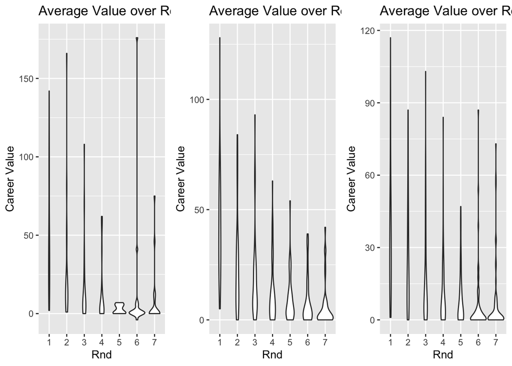

```r
rb_violin <- master_df %>%
  filter(year >= 2000) %>%
  filter(Pos == "RB") %>%
  ggplot(mapping=aes(x=factor(Rnd), y=CarAV)) +
    geom_violin()  +
    labs(x = "Rnd", y = "Career Value", title = "Average Value over Round for RBs") +
    geom_smooth(method=lm)

wr_violin <- master_df %>%
  filter(year >= 2000) %>%
  filter(Pos == "WR") %>%
  ggplot(mapping=aes(x=factor(Rnd), y=CarAV)) +
    geom_violin()  +
    labs(x = "Rnd", y = "Career Value", title = "Average Value over Round for WRs") +
    geom_smooth(method=lm)

grid.arrange(qb_violin, rb_violin, wr_violin, ncol=3)
```

# Part 4: Machine Learning

## Predicting the Rookie Offensive MVP